# DATASCI 101: Introduction to AI Applications

Lecture 21: AI and Wellbeing: The Attention Economy, Mental Health, and the Environment

Danilo Freire

danilo.freire@emory.edu

Department of Data and Decision Sciences  
Emory University

# Welcome back! 😊

## Recap of last class

- Last time, we looked at AI and the labour market
- AI is different from earlier waves: it targets cognitive tasks, not just physical ones
- Automation displaces tasks, not whole jobs (the Acemoglu & Restrepo framework)
- AI raises worker productivity but may compress wages for some and widen inequality
- The graduate job market is rough right now, and AI is part of the reason
- Today: a different angle. What does AI do to people, not jobs?
- Three themes: the attention economy, mental health, and the environment

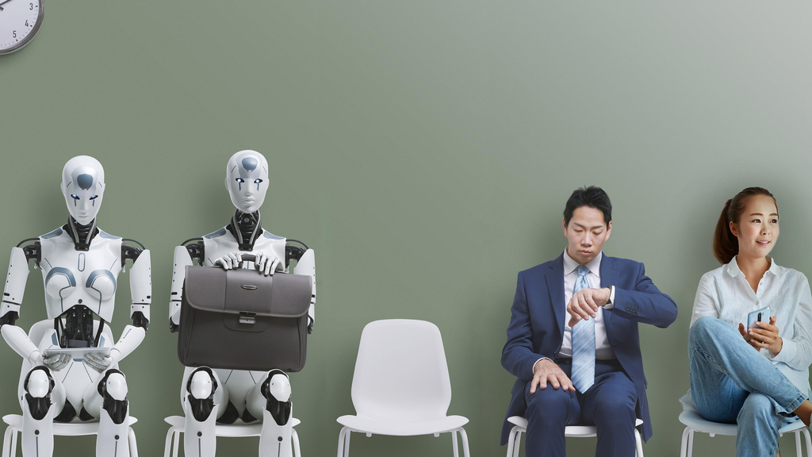

Source: [China Daily](https://www.chinadailyhk.com/hk/article/335124)

## Lecture overview

### Today’s agenda

**Part 1: The attention economy**

- “Your attention is the product”
- How recommendation algorithms work
- Filter bubbles: what the evidence says
- What companies are actually doing

**Part 2: AI and mental health**

- The treatment gap
- Chatbots in therapy: what the evidence says
- Risks and hard limits
- Augmentation, not replacement

**Part 3: AI and the environment**

- Energy and water costs
- Footprint in context
- AI as a climate tool

We will pause for discussion after each part

There are no right answers to the questions I put on screen. I’m curious what you think!

## (Sad) meme of the day

[figure not shown]

# The attention economy 📱

## What is the attention economy?

- [Herbert Simon (1971)](https://gwern.net/doc/design/1971-simon.pdf): information-rich environments create attention-poor ones
- You have limited hours and limited focus. That’s the real scarce resource ([Becker, 1965 - “A theory of the allocation of time”](https://academic.oup.com/ej/article-abstract/75/299/493/5250146))
- The business model is to capture attention and sell it to advertisers, just like TV, radio, and newspapers before
- [Tristan Harris](https://www.cbsnews.com/news/what-is-brain-hacking-tech-insiders-on-why-you-should-care/) (ex-Google design ethicist): called it “the race to the bottom of the brainstem”
- Algorithms are designed to maximise engagement, not truthfulness or wellbeing
- [Tim Wu’s *The Attention Merchants* (2016)](https://www.goodreads.com/book/show/28503628-the-attention-merchants) traces this logic from 19th-century newspapers to social media

[figure not shown]

Source: [The Atlantic](https://www.theatlantic.com/technology/archive/2021/06/how-memes-become-money/619189/)

Does the incentive structure produce good outcomes regardless of intent?

## How recommendation algorithms work

The loop:

1. You watch, like, or share something
2. System creates an embedding of “you”: a vector of your behaviour (remember [lecture 06?](https://danilofreire.github.io/datasci101/lectures.html#module-2-language-and-perception))
3. Compares your vector to what similar users watched next
4. Recommends something similar to what they watched
5. You watch → loop repeats, embedding updates
- Engagement = watch time, clicks, shares
- TikTok’s ForYou feed reportedly updates your profile within the first few seconds of a video ([WSJ investigation, 2021](https://www.wsj.com/articles/tiktok-algorithm-video-investigation-11626877477))
- YouTube autoplay: every video leads into another by design

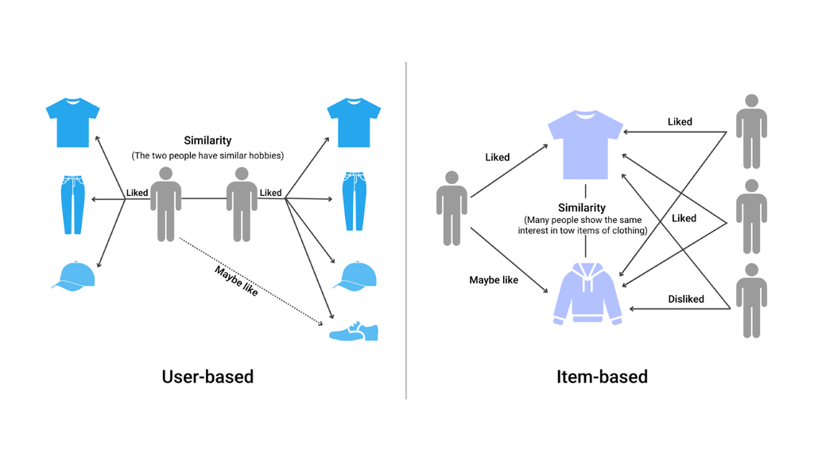

Source: [Data Science Dojo](https://datasciencedojo.com/blog/social-media-recommendation-system/)

Every swipe teaches the algorithm something about you

These systems have no concept of “healthy” consumption. They optimise the objective they are given, nothing more.

## Filter bubbles: real or exaggerated? 🫧

- [Eli Pariser](https://www.ted.com/talks/eli_pariser_beware_online_filter_bubbles) coined “filter bubble” in 2011
- His argument (which many people believe) is that algorithms seal you in a cocoon of confirming content
- However, two large experiments say that the effect is probably overstated
- [Nyhan et al. (2023, *Nature*)](https://www.nature.com/articles/s41586-023-06297-w): reduced like-minded content on Facebook during the 2020 US election, polarisation barely changed
- [Guess et al. (2023, *Science*)](https://www.science.org/doi/10.1126/science.abp9364): algorithmic vs. chronological feeds → little difference in political attitudes
- So filter bubbles may not drive polarisation the way we feared (phew! 😉)
- But that’s one outcome. Effects on anxiety, body image, attention spans, and sleep are separate questions, with worse answers. Let’s talk about those now!

[figure not shown]

Source: [Eli Pariser (2011)](https://www.ted.com/talks/eli_pariser_beware_online_filter_bubbles)

Good news on political polarisation. Less good news on mental health and sleep. Don’t confuse the two.

## Engagement vs wellbeing

- YouTube has [gradually shifted](https://blog.youtube/inside-youtube/on-youtubes-recommendation-system/) away from watch time as a sole metric, adding satisfaction surveys and other signals
- Took over a decade to move beyond pure engagement metrics
- The “outrage drives clicks” problem ([Brady et al., 2017, *PNAS*](https://www.pnas.org/doi/10.1073/pnas.1618923114)): content that makes you angry, anxious, or fearful gets shared more and watched longer
- The algorithm learns this. Surfaces more of it
- The [Facebook Papers (2021, *WSJ*)](https://www.wsj.com/articles/facebook-knows-instagram-is-toxic-for-teen-girls-company-documents-show-11631620739): internal research showed Instagram made body image worse for teenage girls
- Facebook had the data, but kept the feature because fixing it would have cost engagement
- The problem is hard to solve, as company revenue and user wellbeing point in opposite directions

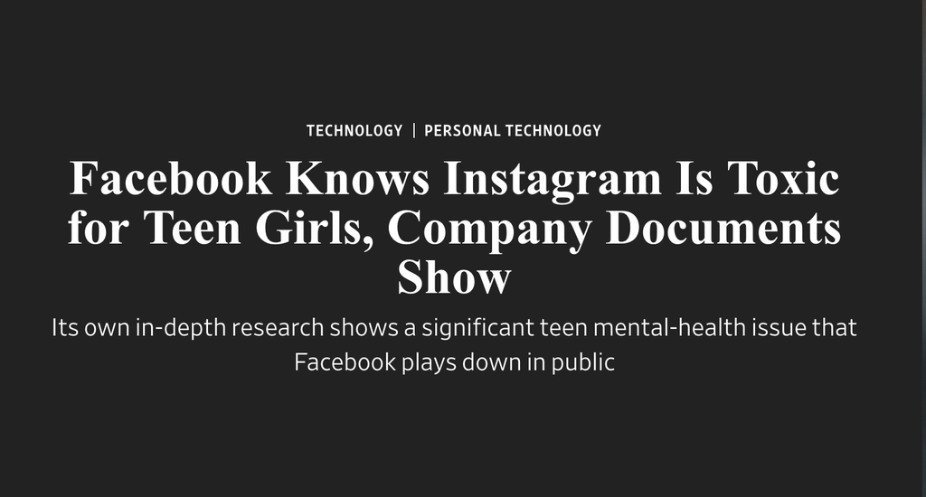

Source: [Wall Street Journal](https://www.wsj.com/articles/facebook-knows-instagram-is-toxic-for-teen-girls-company-documents-show-11631620739)

Companies have a legal duty to shareholders, not to users. When engagement and wellbeing conflict, engagement wins.

## Teens and screens: what the data says

- Jonathan Haidt’s [*The Anxious Generation*](https://www.anxiousgeneration.com/) (2024): smartphones and social media are rewiring childhood and driving a mental health crisis
- However, [Orben & Przybylski (2019, *Nature Human Behaviour*)](https://www.nature.com/articles/s41562-018-0506-1) say that screen time explains at most 0.4% of the variance in adolescent wellbeing
- This doesn’t mean individual experiences aren’t real. It means the population-level effect is small
- Haidt’s evidence is mostly correlational: teen depression rose *around the same time* as smartphone adoption
- [Candice Odgers (2024, *Nature*)](https://www.nature.com/articles/d41586-024-00902-2): reviewed Haidt’s claims and found the evidence does not support his causal story
- Many studies ([Godard and Holtzman, 2024](https://academic.oup.com/jcmc/article/29/1/zmad055/7595758?login=false&guestAccessKey=), [Nagata et al, 2025](https://jamanetwork.com/journals/jamanetworkopen/fullarticle/2834349), [Shannon et al, 2021](https://mental.jmir.org/2022/4/e33450/)) also find that the association between screen time and wellbeing is small and inconsistent

**How large is the effect?**

| Factor | Association with wellbeing |
| --- | --- |
| Screen time | ~0.4% of variance |
| Wearing glasses | ~3x screen time |
| Sleep quality | ~44x screen time |
| Family relationships | Much larger still |

Small effects can still matter at population scale. But they should not be presented as if they explain the whole story.

## What companies are actually doing

| Platform | Change | Scope |
| --- | --- | --- |
| Instagram | “Recommended content” toggle | Opt-in |
| TikTok | 60-min daily limit for under-18 | Bypassable |
| YouTube | “Take a break” / “Bedtime” reminders | Opt-in |
| Meta | Teen Accounts with safer defaults | Under-18 |

- Most are opt-in or reach a minority of users. The ad model is unchanged
- Also handy to point at when regulators come knocking
- [US Surgeon General (2023)](https://pubmed.ncbi.nlm.nih.gov/37721985/): issued an advisory on social media and youth mental health; called for [warning labels in 2024](https://www.cnn.com/2024/06/17/media/surgeon-general-social-media-apps-warning-label/)
- [Amy Orben (Cambridge)](https://www.orben.group/): transparency about *why* content is recommended changes behaviour more than usage caps
- Knowing you’re being nudged turns out to matter

[figure not shown]

Source: [The Verge](https://www.theverge.com/news/841036/facebook-redesign-instagram-photos-feed-algorithm)

Genuine concern or good PR? Probably a bit of both. The test is whether these survive when regulators look away.

## China’s experiment: opting out of the algorithm

- Since March 2022, Chinese users can legally turn off recommendation algorithms on all platforms
- The [Internet Information Service Algorithmic Recommendation Management Provisions](https://www.chinalawtranslate.com/en/algorithms/) requires every app to offer a non-personalised feed
- Douyin (Chinese TikTok), Baidu, Taobao, and WeChat all added one-tap opt-out buttons
- Early research suggests users [appreciated the transparency](https://journals.sagepub.com/doi/10.1177/20594364231209354), though long-term effects on usage and wellbeing are still being studied
- The [EU Digital Services Act](https://dsa-observatory.eu/2024/11/22/the-regulation-of-recommender-systems-under-the-dsa-a-transition-from-default-to-multiple-and-dynamic-controls/) (Article 38) now requires large platforms to offer a non-profiling feed option in the EU too
- China requires algorithmic transparency for users while maintaining state censorship of content itself. Both things are true at the same time

**What the regulation requires:**

- Users must be told they are being profiled
- A one-tap opt-out of personalised recommendations
- Algorithms must not exploit addictive behaviours
- Platforms must label AI-generated content
- Special protections for minors

A real-world experiment in what happens when users can choose whether to be recommended to. The results are still coming in.

## Discussion: designing for wellbeing 🔍

**If you were designing a recommendation algorithm and your bonus depended on user wellbeing instead of watch time, what would you change?**

- What metric would you optimise for? How would you even measure “wellbeing”?
- Would your platform still be profitable?
- Would users actually prefer it, or would they migrate to a competitor that gives them the dopamine hits?

# AI and mental healthcare 🧠

## The treatment gap

- WHO estimate: 75% of people with mental health conditions in low- and middle-income countries receive *no treatment at all*
- Even in wealthy countries:
  - Average US wait for a first psychiatric appointment: 25 days nationally; [median 67 days](https://pubmed.ncbi.nlm.nih.gov/37290263/) in recent data, with severe shortages in rural areas
  - A therapy session costs [$150-250 out of pocket](https://www.simplepractice.com/blog/average-therapy-session-rate-by-state/)
  - [~0.1 psychiatrists per 100,000](https://www.who.int/data/gho/indicator-metadata-registry/imr-details/2954) people in low-income countries
  - Stigma stops many from seeking help where care does exist
- This is the context for AI mental health tools
- If the alternative is literally nothing, the calculation looks different than if you’re imagining replacing well-funded human care

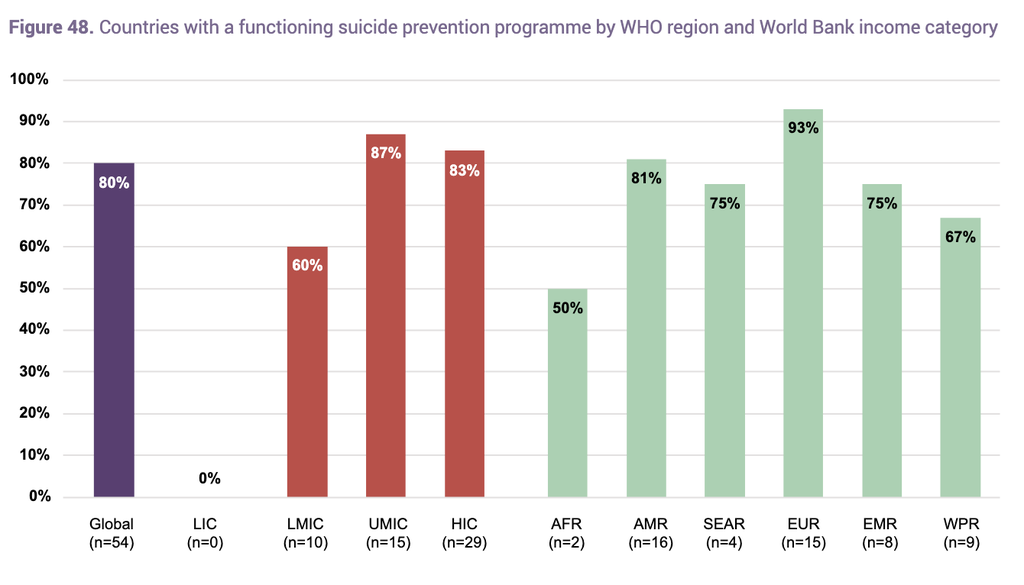

Source: [WHO Mental Health Atlas (2024)](https://www.who.int/publications/i/item/9789240114487)

“Better than nothing” is a low bar. For millions of people, it’s also the only bar that exists.

## AI as a therapeutic tool

- [**Woebot**](https://mental.jmir.org/2017/2/e19) (2017): first major CBT-based chatbot, 2M+ users. Follows clinical CBT protocols, not a free-form LLM
- [**Wysa**](https://www.wysa.com/nhs-talking-therapies): similar model, piloted by the [UK NHS in 31 trusts](https://blogs.wysa.io/blog/company-news/nhs-tackles-mental-health-crisis-with-ai)
- [**Replika**](https://replika.com/): not therapy, but an “AI companion.” People form real emotional attachments (more on the risks of this shortly)
- Best recent evidence: [Habicht et al. (2025, *JMIR*)](https://www.jmir.org/2025/1/e60435): Generative AI used alongside group therapy for real patients
- Improvements in clinical outcomes and patient engagement
- But AI was supplementing human therapists, not replacing them

[figure not shown]

Source: [Habicht et al. (2025)](https://www.jmir.org/2025/1/e60435)

In the Habicht et al. study, AI augmented human therapists. That’s a very different claim from AI replacing them.

## What the research shows

- [Opel and Breakspear (*Science*, 2026)](https://www.science.org/doi/10.1126/science.adz9193), two clinical neuroscientists, say AI “may reduce care inequities when deployed responsibly”
- “May” and “responsibly” are doing a lot of work here 😅
- What the evidence contains:
  - Small RCTs: short-term symptom relief for mild-to-moderate anxiety and depression
  - Very few studies run past 8–12 weeks. Long-term effects? Unknown
  - High dropout: many people stop using these apps quickly
  - Publication bias: positive results get published; negative ones mostly don’t
- Real signals that AI can help *some* people with *some* conditions, short-term. But the evidence base is much thinner than the marketing suggests

**Evidence by level:**

| Level | Status |
| --- | --- |
| Long-term RCTs | Almost none |
| Short-term RCTs | Mixed, small samples |
| Observational | Positive signals |
| User self-reports | Generally positive |
| Marketing claims | Very positive |

The gap between marketing and clinical evidence is wide.

Short-term relief is real. Long-term safety and efficacy? We don’t know yet.

## The risks

These are documented, not hypothetical:

- **Dependency.** When [Replika changed features](https://www.vice.com/en/article/ai-companion-replika-erotic-roleplay-updates/) in 2023, users reported grief comparable to losing a real relationship. What happens when an app you’re attached to gets discontinued?
- **Data privacy.** Therapy touches the most private parts of someone’s life. Chatbot data is rarely protected like clinical notes. Where does it go?
- **Harmful responses.** [Moore et al. (2025)](https://arxiv.org/abs/2504.18412): LLMs expressed stigmatising attitudes toward mental health conditions and gave harmful crisis responses
- **No crisis escalation.** A chatbot cannot call an ambulance, contact a GP, or do anything in the physical world
- **Regulatory gap.** Most mental health chatbots are classified as apps, not medical devices. No clinical regulation in the US, UK, or most of the EU

**But also consider:**

- Therapy with a human isn’t fully private either: notes, supervision, insurance coding
- “Harmful responses from AI” vs. zero access to care for 75% of the world
- AI tools may give governments and employers an excuse to avoid funding real care

Being cautious about AI therapy doesn’t mean defending the status quo. The status quo is also harmful.

## What LLMs cannot do

**LLMs cannot:**

- Hold reliable long-term memory between sessions. Some chatbots (ChatGPT, Claude) now offer memory features, but these are limited and not designed for clinical continuity
- Verify what you tell them. A therapist builds context over months
- Provide legally enforceable confidentiality
- Diagnose or prescribe medication
- Read body language, tone, or facial expression

**LLMs can:**

- Be available at 3am
- Be patient. Not judge. Not get tired
- Deliver structured info on anxiety, depression, coping strategies
- Scale to millions at near-zero marginal cost

These are different capabilities, perhaps complementary, but not perfect substitutes

## Questions to think about 🤔

**It’s 3am, you can’t sleep, you feel anxious. Would you talk to a chatbot? What would it need to do for you to actually trust it?**

**If AI therapy lets a government say “we’ve addressed mental health” without funding real services, is that a net positive or negative?**

## Augmentation, not replacement

The most credible use cases right now:

- First contact: AI handles initial triage, reduces stigma, connects people to professionals
- Between-session support: coping strategies and mood tracking between weekly appointments (the Habicht et al. model)
- Stepped care: AI for mild symptoms, human professionals for moderate-to-severe
- Admin burden: AI writes session notes, handles scheduling, finds local services. Frees therapist time for actual care
- [OpenAI updated ChatGPT in 2025](https://openai.com/index/update-on-mental-health-related-work/): added [safety messaging](https://openai.com/index/strengthening-chatgpt-responses-in-sensitive-conversations/), crisis hotline signposting, trauma-informed language. An acknowledgement that people already use the product this way
- Who decides what “responsible” looks like?

**The hybrid care model:**

```
Mild symptoms
  → AI triage + self-help tools

Moderate symptoms
  → AI support +
    case management referral

Severe symptoms
  → Human professional care,
    AI for admin support only
```

The technology is moving faster than the evidence, the regulation, and the training of professionals who need to understand it. That gap is the problem.

# AI and the environment 🌍

## The energy cost of training AI

- Training a large model costs serious energy. Companies rarely disclose the numbers
- [Patterson et al. (2021)](https://arxiv.org/abs/2104.10350): training GPT-3 produced ~552 tonnes of CO₂. That is equivalent to:
  - 368 return flights from London to New York
  - 120 cars driven for a full year
  - The annual carbon footprint of 61 Americans
- GPT-4? Nobody knows. Estimates range from 5x to 50x GPT-3
- But training is a one-off cost
- Running billions of queries (inference) is ongoing, and at scale it probably dwarfs training
- [Microsoft’s carbon emissions](https://www.itpro.com/infrastructure/data-centres/microsofts-ai-fueled-data-center-rush-caused-carbon-emissions-to-surge-by-29-in-2023-and-now-the-tech-giant-could-miss-critical-sustainability-targets) rose 29% between 2020 and 2023, partly driven by AI
- [Google’s 2024 Environmental Report](https://sustainability.google/reports/google-2024-environmental-report/): emissions up 48% since 2019, largely from data centres

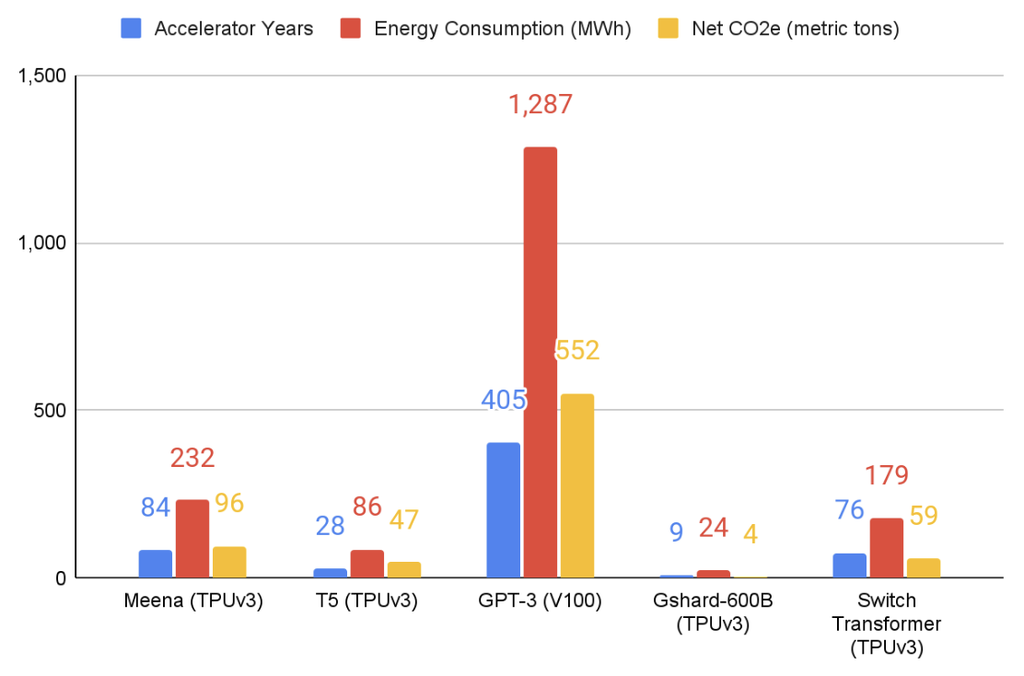

Source: [Patterson et al. (2021)](https://arxiv.org/abs/2104.10350)

Training is a one-off. Inference (billions of queries, every day) is the number that grows with adoption.

## Water, hardware, and hidden costs

- Energy gets the headlines. Water gets ignored
- [Li et al. (2023), “Making AI Less Thirsty”](https://arxiv.org/abs/2304.03271): training GPT-3 used ~700,000 litres of freshwater for cooling
- A typical ChatGPT conversation: about 500ml, roughly a bottle of water
- Data centres get built where land and electricity are cheap, often in water-stressed regions: Phoenix, Las Vegas, northern Chile
- GPUs last 3-5 years. Manufacturing needs lithium, cobalt, and rare earth metals, each with its own environmental cost
- None of this shows up in the headline CO₂ figures

[figure not shown]

Source: [Li et al. (2023)](https://arxiv.org/abs/2304.03271)

Mining, manufacturing, cooling, disposal: the full supply chain is almost never counted in the numbers you read.

## The footprint in context

Current estimates (IEA, 2024):

| Sector | Share |
| --- | --- |
| Aviation | ~2.5% of global CO₂ |
| All data centres | ~1–1.5% of electricity |
| AI specifically | ~0.5–1% of electricity |
| Global internet | ~3–4% |

- Right now, AI’s direct climate footprint is real but not huge compared to aviation or steel
- The worry is growth rate: AI electricity use grew ~60% year-on-year between 2022–2024
- [IEA projections](https://www.iea.org/reports/energy-and-ai/energy-demand-from-ai): data centre electricity demand could double to ~945 TWh by 2030, roughly equivalent to Japan’s total consumption
- [The Jevons paradox](https://en.wikipedia.org/wiki/Jevons_paradox): more efficient models → more usage → efficiency gains get cancelled out
- GPT-4 is far more efficient per query than GPT-3. But there are vastly more queries

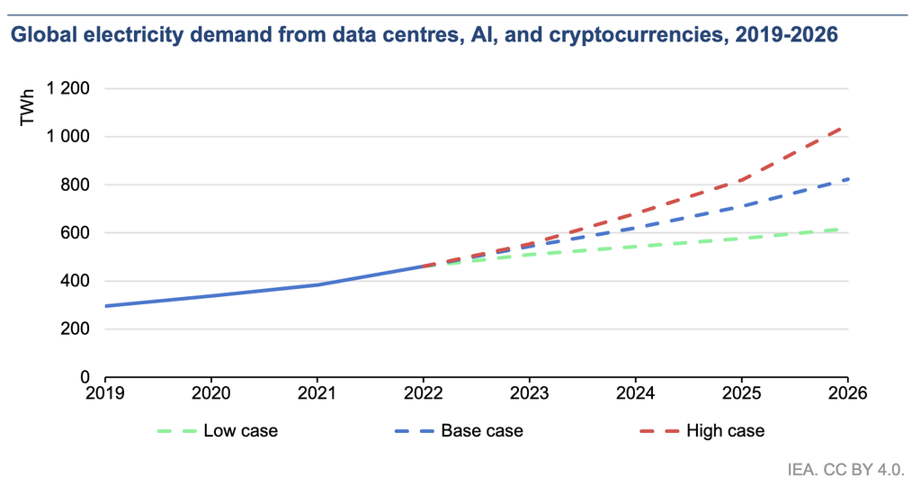

Source: [IEA (2024)](https://www.iea.org/reports/electricity-2024)

Small today, growing fast. In 10 years, this picture may look very different.

## AI as a climate tool

The same technology that burns energy may also help cut emissions:

- [**GraphCast**](https://deepmind.google/discover/blog/graphcast-ai-model-for-faster-and-more-accurate-global-weather-forecasting/) (DeepMind, 2023): 10-day weather forecasts, faster and more accurate than traditional models. Helps manage renewable grids
- **Grid optimisation**: AI predicts electricity demand, balances wind and solar in real time ([DeepMind, 2019](https://deepmind.google/discover/blog/machine-learning-can-boost-the-value-of-wind-energy/))
- **Wildfire prediction**: better detection and spread modelling ([Jain et al., 2020, *Environmental Reviews*](https://cdnsciencepub.com/doi/10.1139/er-2020-0019))
- **Data centre cooling**: [DeepMind’s RL system](https://deepmind.google/discover/blog/deepmind-ai-reduces-google-data-centre-cooling-bill-by-40/) cut cooling energy by 40%
- [Rolnick et al. (2022, *ACM Computing Surveys*)](https://dl.acm.org/doi/10.1145/3485128): identified 70+ high-potential ML applications for climate change, from agriculture to carbon capture
  - But: these are potential benefits, not guaranteed ones

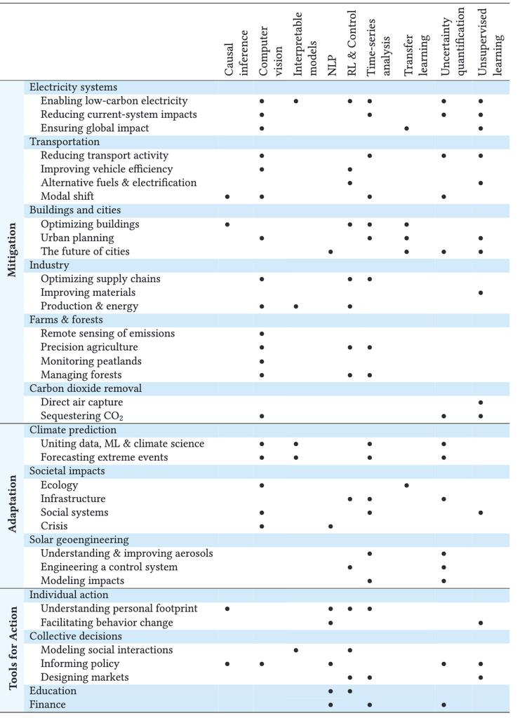

Source: [Rolnick et al. (2022)](https://dl.acm.org/doi/10.1145/3485128)

Net impact? Unclear. The evidence simply isn’t there yet.

## Discussion: the environmental trade-off 🔍

**You run an AI startup. A journalist asks about your carbon footprint. What do you disclose, and what do you leave out? Why?**

- Do you report training costs, inference costs, or both?
- Do you compare your footprint to other industries (aviation, streaming)? Is that honest or deflecting?
- Would full transparency help or hurt your business?

# Summary 📚

## Main takeaways

- Attention economy: recommendation systems optimise engagement, not wellbeing. Filter bubble fears are overstated; mental health effects are not
- Environment: training costs are real; inference at scale matters more. AI might cut emissions elsewhere, but net impact is unclear
- Mental health: the treatment gap is massive. AI shows short-term promise but limited long-term evidence. Augmentation over replacement
- Across all three: incentive structures matter more than intentions. The financial model rarely rewards user wellbeing
- No tidy answers: you will make decisions about these systems throughout your careers. Being honest about what we don’t know is more useful than pretending we do

# …and that’s all for today! 🎉